# COVID-19

Juan Diego Martínez y Fco. Aguilera

22/3/2020

# Librerías:

- **tidyverse** para manipulació y visualización.
- **stringr** para parsear los datos en bruto.
- **lubridate** para trabajar con fechas.
- **ggplot2** para visualización de datos.
- **arules** para reglas de asociación

# Datasets

- **Datadista**: https://github.com/datadista/datasets

```r
knitr::opts_chunk$set(warning = FALSE, message = FALSE, fig.align = "center")
```

```r
library(readr)
library(tidyverse)
library(lubridate)
library(stringr)
library(arules)
require(gridExtra)
theme_set(theme_bw())
```

# Situación en España

> “El director general de la Organización Mundial de la Salud (OMS), Tedros Adhanom Ghebreyesus, ha declarado este miércoles que el coronavirus Covid-19 pasa de ser una epidemia a una pandemia.”

```r
nacional <- read_csv("./datasets/nacional_covid19.csv")
nacional$fecha <- as.Date(nacional$fecha)
```

```r
# fases de confinamiento y desescalada

# fase 0 (confimaniento total)
fase0 <- dmy("15/03/2020")

# fase 1 (deporte y paseos de niños)
fase1 <- dmy("2/05/2020")

# desescalada (fase 2 en adelante. Englobo el resto de fases porque en todas se permite socializar)
fase2 <- dmy("18/05/2020")
```

## Vista general

- ¿Cuándo se superan los 1000 casos diarios? ¿Y los 100 fallecidos?

```r
# calculo los casos nuevos de infectados, hospitalizados y fallecidos
nacional <- nacional %>%
  mutate(casos_nuevos = c(0, diff(casos_total)),
         hospitalizados_nuevos = c(NA, diff(hospitalizados)),
         fallecimientos_nuevos = c(0, diff(fallecimientos)),
         altas_nuevas = c(NA, diff(altas)))

fecha_1000_casos <- nacional %>%
  filter(casos_nuevos >= 1000) %>%
  select(fecha, casos_nuevos) %>%
  head(1) %>%
  first()
fecha_1000_casos
```

```
## [1] "2020-03-12"
```

```r
fecha_100_fallecimientos <- nacional %>%
  filter(fallecimientos_nuevos >= 100) %>%
  select(fecha, fallecimientos_nuevos) %>%
  head(1) %>%
  first()
fecha_100_fallecimientos
```

```
## [1] "2020-03-15"
```

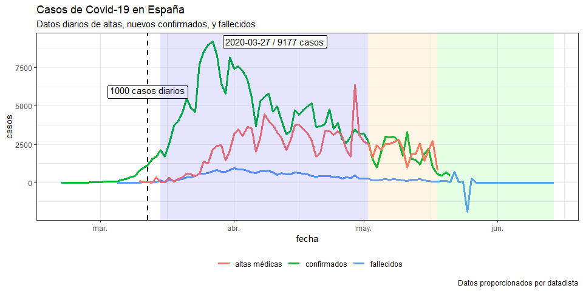

```r
# dia con mas casos nuevos
dia_max <- nacional %>%
  arrange(-casos_nuevos) %>%
  head(1) %>%
  select(fecha, casos_nuevos)

nacional %>%
  ggplot(aes(x = fecha)) +
  geom_line(aes(y=casos_nuevos, color = "confirmados"), size = 1.2) +
  geom_line(aes(y=fallecimientos_nuevos, color = "fallecidos"), size = 1.2) +
  geom_line(aes(y=altas_nuevas, color = "altas médicas"), size = 1.2) +

  geom_vline(aes(xintercept = fecha_1000_casos), linetype = "dashed", size = 1) +
  geom_label(aes(x = fecha_1000_casos, y = +Inf, label = "1000 casos diarios", vjust = 5)) +

  theme(legend.title = element_blank(), legend.position = "bottom") +

  annotate("rect", xmin = fase0, xmax = fase1,
           ymin=-Inf, ymax=Inf, fill = "blue", alpha = .1) +
  annotate("rect", xmin = fase1, xmax = fase2,
           ymin=-Inf, ymax=Inf, fill = "orange", alpha = .1) +
  annotate("rect", xmin = fase2, xmax = max(nacional$fecha),
           ymin=-Inf, ymax=Inf, fill = "green", alpha = .1) +

  geom_label(aes(x = dia_max$fecha, y = dia_max$casos_nuevos, label = paste(dia_max$fecha, "/", dia_max$casos_nuevos, "casos")), hjust = -.1) +


  xlab("fecha") + ylab("casos") +
  labs(title = "Casos de Covid-19 en España", subtitle = "Datos diarios de altas, nuevos confirmados, y fallecidos", caption = "Datos proporcionados por datadista")
```

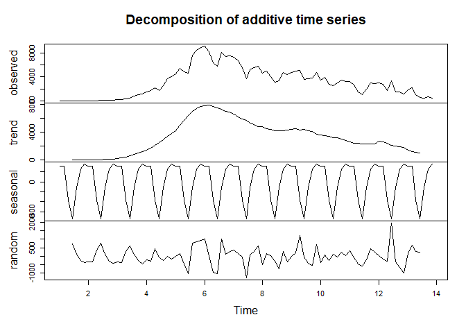

```r
# me quedo con los casos nuevos de cada dia
t <- nacional %>%
  select(casos_nuevos) %>%
  na.omit() %>%
  ts(frequency = 7)
plot(decompose(t))
```

He creado una serie temporal de frecuencia 7 para observar la estacionalidad que vemos en la gráfica anterior.

Podemos observar la tendencia exponencial al principio de la pandemia, y como poco a poco se van reduciendo los nuevos casos. Tambien observamos una estacionalidad de 7 días. Esto podría darse por no acudir al hospital o médico o la no realización de tests los findes de semana.